# The complex link between filter bubbles and opinion polarization

### Marijn A. Keijzer & Michael Mäs

### Contents of this notebook:

- Preliminaries
- Regime → (Homophily → Diversity)
- Clustering → opinion fragmentation
  - Single run analysis
  - Simulation experiment
  - Statistical model
  - Plots: clustering X personalization

The following packages are needed for executing this code.

Note that [defSim](https://marijnkeijzer.github.io/defSim/) is currently only [available through github](https://github.com/marijnkeijzer/defSim), so can be installed by downloading the repository there, or by running the following pip command:

`pip install git+https://github.com/marijnkeijzer/defSim`

```python
import defSim as ds

import networkx as nx              # used to handle the networkX object
import matplotlib as mpl
import matplotlib.pyplot as plt    # for plotting
import numpy as np                 # includes some useful math tools
import random                      # used to set seeds for random but replicable drawing
import itertools
import pandas as pd
import seaborn as sns
```

We will need a function for plotting opinion trajectories:

```python
def plot_opinions_2D(opinions,title="",subplot=False):
    if not subplot:
        font = {'family' : 'DejaVu Sans',
                'weight' : 'normal',
                'size'   : 14}
        plt.rc('font', **font)
        plt.figure(figsize=[16,6])
        plt.title(title)

        # line colors
    colormap = plt.get_cmap('hsv')

    plt.xlabel('Time')
    plt.ylabel('Opinions')

    a=np.array(opinions).transpose()
    plt.plot(a[1])

    for i in range(len(G)):
        plt.plot(a[i],color=colormap(a[i][0]))
```

## Regime → (Homophily → Diversity)

Building upon the dissemination of culture model by Axelrod (1997) we implement a selection-influence model on beliefs with an alternative dependency between the cultural overlap and probability of interaction between two agents. This function lets us vary the strength of homophily with parameter $h$, to affect the proability of interaction $p$ as a function of cultural overlap $x_{ij}$ like so:

$$p= \begin{cases} (\frac{1}{2})^{1-h}x^h, & \text{if } x\leq.5\\ 1-(\frac{1}{2})^{1-h}(1-x)^h, & \text{if } x > .5\\ \end{cases}$$

This function looks like:

[figure not shown]

With this function, we ran the following experiment (ran remotely because of computationally expensive simulation):

```
#!/usr/bin/env python

import defSim as ds
import time

exp = ds.Experiment(seed=269,
                    influence_function="axelrod",
                    attributes_initializer="random_categorical",
                    attribute_parameters={"num_features": [5],
                                          "num_traits": [15]},
                    influence_parameters={"homophily": [.25, .5, 1, 2, 4]},     # .125 & 8 were ran stand-alone
                    topology="grid",
                    stop_condition="strict_convergence",
                    max_iterations=9999999,
                    network_parameters={"neighborhood": "moore",
                                        "num_agents": 100},
                    communication_regime=["one-to-one", "one-to-many"],
                    output_realizations=["AverageDistance", "Homogeneity", "Regions", "Isolates",
                                         "SuccessfullInfluence", "Ticks"],
                    repetitions=200)

start = time.time()
my_results = exp.run(parallel=True)
end = time.time()
print("Simulation completed in", round(end - start), "seconds")
my_results.to_csv('AxelrodWithHomophily.csv', index=False)
```

```python
# data from simulations run on the HPC

df = pd.read_csv('AxelrodWithHomophily.csv')
df = df.append(pd.read_csv('AxelrodWithHomophily_extreme_low.csv'), ignore_index=True)     # ran seperately, because
df = df.append(pd.read_csv('AxelrodWithHomophily_extreme_high.csv'), ignore_index=True)    # computationally expensive

x_tick_labels = ['weakest\n(h=.125)', 'weaker\n(h=.25)', 'weak\n(h=.5)',
                 'moderate\n(h=1)',
                 'strong\n(h=2)', 'stronger\n(h=4)', 'strongest\n(h=8)']

df.columns = [n if n != "communication_regime" else "Communication Regime" for n in df.columns]
```

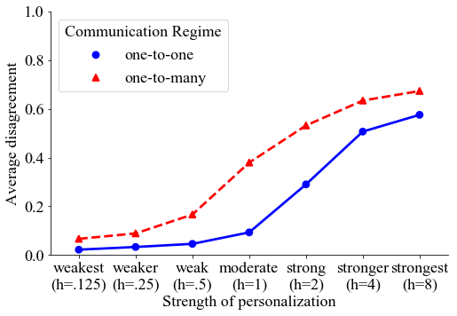

```python
font = {'family':'Times New Roman', 'weight':'normal', 'size':18}
plt.rc('font', **font)

plt.figure(figsize=(10,5))
g = sns.catplot(x="homophily", y="AverageDistance", hue="Communication Regime",
                data=df,
                palette={"one-to-one": "blue", "one-to-many": "red"},
                linestyles=["-", "--"],
                dodge=0,
                linewidth=3, kind="point",
                #capsize=.1,
                ci=None,
                markers=["o", "^"],
                legend_out=False,
                height=5,
                aspect=1.5)

g.set(ylim=[0, 1],
      xlabel='Strength of personalization',
      ylabel='Average disagreement',
      xticklabels=x_tick_labels)

plt.show()
```

## Clustering → opinion fragmentation

Parameters:

```python
def simulation_run(N=120,
                   K=10,
                   rewiring=0,
                   confidence_level=0.2,
                   max_ticks=10000,
                   seed_run=random.randint(10000,99999),
                   record_opinions=False):
    random.seed(seed_run)

    G = ds.generate_network("watts_strogatz_graph", n=N, k=K, p=rewiring)
    ds.initialize_attributes(G, realization="random_continuous", num_features=1)
    calculator = ds.dissimilarity_calculator.select_calculator("euclidean")
    calculator.calculate_dissimilarity_networkwide(G)

    iterator = 0
    if record_opinions: opinions_exp1 = []

    while iterator < max_ticks:
        agent_i = ds.focal_agent_sim.select_focal_agent(G,"random")
        agent_j = ds.neighbor_selector_sim.select_neighbors(G,"random",agent_i,"one-to-many")

        ds.influence_sim.spread_influence(G, "bounded_confidence", agent_i, agent_j, "one-to-many",
                                          calculator, convergence_rate=0.5, confidence_level=confidence_level)
        if record_opinions: opinions_exp1.append(list(nx.get_node_attributes(G,'f01').values()))
        iterator += 1
        if not any([True for x in nx.get_edge_attributes(G,'dist').values() if 0.01 < x < confidence_level]):
            break

    if record_opinions:
        return(opinions_exp1)
    else:
        list_of_clusters = ds.ClusterFinder.create_output(G,cluster_dissimilarity_threshold=confidence_level)
        return(dict(
            seed = seed_run,
            N = N,
            K = K,
            rewiring = rewiring,
            confidence_level = confidence_level,
            ticks = iterator,
            number_of_subgroups = len(list_of_clusters),
            size_biggest_subgroup = list_of_clusters[0],
            transitivity=nx.transitivity(G)
        ))
```

## Single run analysis

```python
# EXPERIMENT 1: weak personalization & high clustering
opinions_exp1 = simulation_run(rewiring=0,confidence_level=0.3,seed_run=834,record_opinions=True)
# EXPERIMENT 2: weak personalization & low clustering
opinions_exp2 = simulation_run(rewiring=0.35,confidence_level=0.3,seed_run=731,record_opinions=True)
# EXPERIMENT 3: strong personalization & high clustering
opinions_exp3 = simulation_run(rewiring=0,confidence_level=0.2,seed_run=141,record_opinions=True)
# EXPERIMENT 4: strong personalization & low clustering
opinions_exp4 = simulation_run(rewiring=0.35,confidence_level=0.2,seed_run=578,record_opinions=True)
```

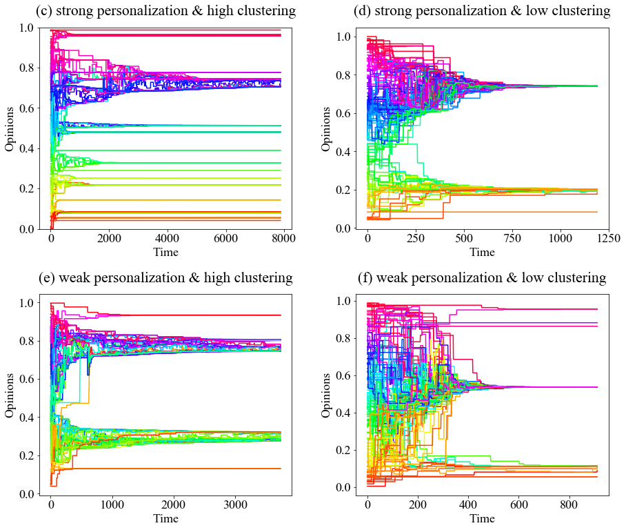

```python
plt.figure(figsize=[13,11])
font = {'family':'Times New Roman', 'weight':'normal', 'size':18}
plt.rc('font', **font)
plt.ylim(0,1)

G = ds.generate_network("watts_strogatz_graph", n=120, k=40, p=0)

plt.subplot(221)
plt.title('(c) strong personalization & high clustering',y=1.04)
plt.ylim(0,1)
plot_opinions_2D(opinions_exp3,subplot=True)

plt.subplot(222)
plt.title('(d) strong personalization & low clustering',y=1.04)
plot_opinions_2D(opinions_exp4,subplot=True)

plt.subplot(223)
plt.title('(e) weak personalization & high clustering',y=1.04)
plot_opinions_2D(opinions_exp1,subplot=True)

plt.subplot(224)
plt.title('(f) weak personalization & low clustering',y=1.04)
plot_opinions_2D(opinions_exp2,subplot=True)

plt.tight_layout()
```

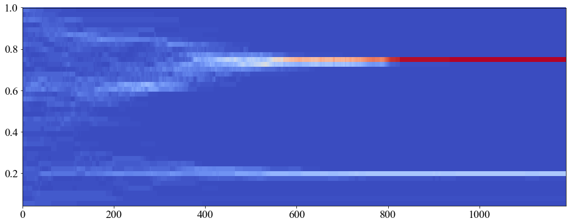

```python
x = [i for i in range(len(opinions_exp4)) for _ in range(len(opinions_exp4[0]))]
y = [y for x in opinions_exp4 for y in x]

plt.figure(figsize=[16,6])

cmap = plt.cm.coolwarm
cmaplist = [cmap(i) for i in range(cmap.N)]
#cmaplist[0] = (1,1,1,1)
cmap = mpl.colors.LinearSegmentedColormap.from_list('Custom cmap', cmaplist, cmap.N)

fig = plt.hist2d(x,y,bins=[len(opinions_exp4),40],cmap=cmap)
```

```
G1
	# of edges =		 600
	transitivity =		 0.6666666666666666
G2
	# of edges =		 600
	transitivity =		 0.21815258174021798
```

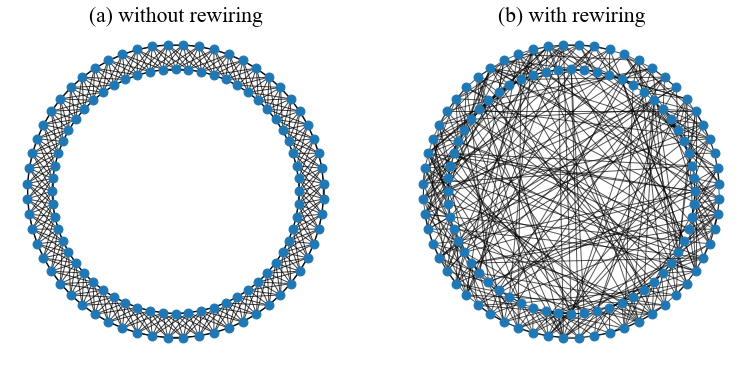

```python
N=120
K=10
rewiring=[0,0.35]

G1 = ds.generate_network("watts_strogatz_graph",n=N, k=K, p=rewiring[0])
G2 = ds.generate_network("watts_strogatz_graph",n=N, k=K, p=rewiring[1])

print('G1\n\t# of edges =\t\t',nx.number_of_edges(G1))
print('\ttransitivity =\t\t',nx.transitivity(G1))
print('G2\n\t# of edges =\t\t',nx.number_of_edges(G2))
print('\ttransitivity =\t\t',nx.transitivity(G2))

pos1 = nx.circular_layout(G1,scale=1)
pos2 = nx.circular_layout(G1,scale=1.2)
pos = dict()
for k in pos1.keys():
    if k % 2 == 0:  pos[k] = pos1[k]
    else:           pos[k] = pos2[k]

plt.figure(figsize=[13,6])
font = {'family':'Times New Roman', 'weight':'normal', 'size':18}
plt.rc('font', **font)
plt.ylim(0,1)

plt.subplot(121, title='(a) without rewiring')
nx.draw_networkx_nodes(G1, pos=pos, node_size=80)
nx.draw_networkx_edges(G1, pos=pos, alpha=.75)
plt.axis('off')
plt.subplot(122, title='(b) with rewiring')
nx.draw_networkx_nodes(G2, pos=pos, node_size=80)
nx.draw_networkx_edges(G2, pos=pos, alpha=.65)
plt.axis('off')
plt.show()
```

## Simulation experiment

```python
def simulation_experiment(personalization=[0.1,0.2,0.3],rewiring_iter=[0,.175,.35],repetitions=3):
    random.seed(123)
    lod = []
    for i,j in itertools.product(personalization,rewiring_iter):
        for x in range(repetitions):
            rundict = dict(personalization=i,
                           rewiring_iter=j)
            rundict.update(simulation_run(rewiring=j,confidence_level=i,max_ticks=10,seed_run=random.randint(10000,99999)))
            lod.append(rundict)
    return(lod)
```

```python
output = simulation_experiment(repetitions=100)
df = pd.DataFrame(output)
```

## Statistical model: poisson regression

```python
from statsmodels.genmod.generalized_estimating_equations import GEE
from statsmodels.genmod.cov_struct import (Exchangeable,
    Independence,Autoregressive)
from statsmodels.genmod.families import Poisson
```

```python
fam = Poisson()
ind = Independence()
model1 = GEE.from_formula("number_of_subgroups ~ personalization + rewiring + (personalization * rewiring)", "seed", data=df, cov_struct=ind, family=fam)
result1 = model1.fit()
print(result1.summary())
```

```
                               GEE Regression Results
===================================================================================
Dep. Variable:         number_of_subgroups   No. Observations:                  900
Model:                                 GEE   No. clusters:                      818
Method:                        Generalized   Min. cluster size:                   1
                      Estimating Equations   Max. cluster size:                   3
Family:                            Poisson   Mean cluster size:                 1.1
Dependence structure:         Independence   Num. iterations:                     2
Date:                     Mon, 06 Jan 2020   Scale:                           1.000
Covariance type:                    robust   Time:                         17:13:25
============================================================================================
                               coef    std err          z      P>|z|      [0.025      0.975]
--------------------------------------------------------------------------------------------
Intercept                    5.1037      0.029    177.853      0.000       5.047       5.160
personalization            -14.7029      0.220    -66.735      0.000     -15.135     -14.271
rewiring                    -0.9313      0.165     -5.658      0.000      -1.254      -0.609
personalization:rewiring    -3.4936      1.200     -2.912      0.004      -5.845      -1.142
==============================================================================
Skew:                          0.5093   Kurtosis:                       2.1677
Centered skew:                 0.0788   Centered kurtosis:             13.2338
==============================================================================
```

```python
df.columns
```

```
Index(['K', 'N', 'confidence_level', 'number_of_subgroups', 'personalization',
       'rewiring', 'rewiring_iter', 'seed', 'size_biggest_subgroup', 'ticks',
       'transitivity'],
      dtype='object')
```

```python
df.columns = ['K', 'N', 'confidence_level', 'number_of_subgroups', 'personalization',
       'Clustering', 'rewiring_iter', 'seed', 'size_biggest_subgroup', 'ticks', 'transitivity']
df['Clustering'] = df['Clustering'].replace([0, 0.175, 0.35], ['strong', 'moderate', 'weak'])
```

```python
df.groupby('Clustering').describe()['transitivity']
```

| Clustering | count | mean | std | min | 25% | 50% | 75% | max |
| --- | --- | --- | --- | --- | --- | --- | --- | --- |
| moderate | 300.0 | 0.383558 | 0.019199 | 0.325472 | 0.370892 | 0.383851 | 0.395190 | 0.432153 |
| strong | 300.0 | 0.666667 | 0.000000 | 0.666667 | 0.666667 | 0.666667 | 0.666667 | 0.666667 |
| weak | 300.0 | 0.216155 | 0.015958 | 0.176661 | 0.203815 | 0.217317 | 0.226600 | 0.257267 |

```python
df.groupby('personalization').describe()['number_of_subgroups']
```

| personalization | count | mean | std | min | 25% | 50% | 75% | max |
| --- | --- | --- | --- | --- | --- | --- | --- | --- |
| 0.1 | 300.0 | 31.263333 | 7.405186 | 15.0 | 26.0 | 31.0 | 36.0 | 48.0 |
| 0.2 | 300.0 | 5.693333 | 2.785406 | 1.0 | 3.0 | 5.0 | 8.0 | 16.0 |
| 0.3 | 300.0 | 1.983333 | 1.067797 | 1.0 | 1.0 | 2.0 | 3.0 | 6.0 |

```python
G.number_of_edges()
```

```
2400
```

### Plots: clustering X personalization

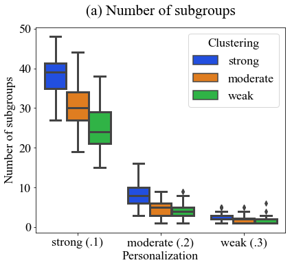

```python
plt.figure(figsize=[6.5,5.5])

plt.title('(a) Number of subgroups',y=1.04)
ax = sns.boxplot(x="confidence_level", y="number_of_subgroups", hue="Clustering",
                  data=df, palette='bright',linewidth=3)
ax.set(xlabel='Personalization',
       ylabel='Number of subgroups',
       xticklabels=['strong (.1)','moderate (.2)','weak (.3)'])
plt.show()
```

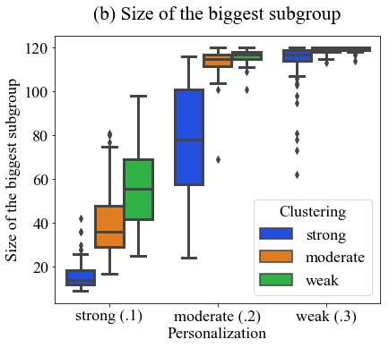

```python
plt.figure(figsize=[6.5,5.5])

plt.title('(b) Size of the biggest subgroup',y=1.04)
ax = sns.boxplot(x="confidence_level", y="size_biggest_subgroup", hue="Clustering",
                  data=df, palette='bright',linewidth=3)
ax.set(xlabel='Personalization',
       ylabel='Size of the biggest subgroup',
       xticklabels=['strong (.1)','moderate (.2)','weak (.3)'])
plt.show()
```

#### References

Axelrod, R. (1997). The dissemination of culture: A model with local convergence and global polarization. *Journal of conflict resolution, 41*(2), 203-226.